# Contrucción Matriz Q

Peliculas

```r
#llibreries
library(readr)
library(tidyverse)
library(rstan)
```

```r
movies  <- read_csv("data/movies.csv")
ratings <- read_csv("data/ratings.csv")
```

```r
#extraer generos de las pelis
todos_los_generos <- movies %>%
  separate_rows(genres, sep = "\\|") %>%   # separar por |
  distinct(genres) %>%
  arrange(genres)

print(todos_los_generos)
```

```
# A tibble: 20 × 1
   genres
   <chr>
 1 (no genres listed)
 2 Action
 3 Adventure
 4 Animation
 5 Children
 6 Comedy
 7 Crime
 8 Documentary
 9 Drama
10 Fantasy
11 Film-Noir
12 Horror
13 IMAX
14 Musical
15 Mystery
16 Romance
17 Sci-Fi
18 Thriller
19 War
20 Western
```

```r
#veamos cuantas pelis tiene cada genero
# Contar cuántas películas tiene cada género
conteo_generos <- movies %>%
  separate_rows(genres, sep = "\\|") %>%
  dplyr::filter(genres != "(no genres listed)") %>%
  count(genres, sort = TRUE)   # sort=TRUE ordena de mayor a menor

print(conteo_generos)
```

```
# A tibble: 19 × 2
   genres          n
   <chr>       <int>
 1 Drama       13344
 2 Comedy       8374
 3 Thriller     4178
 4 Romance      4127
 5 Action       3520
 6 Crime        2939
 7 Horror       2611
 8 Documentary  2471
 9 Adventure    2329
10 Sci-Fi       1743
11 Mystery      1514
12 Fantasy      1412
13 War          1194
14 Children     1139
15 Musical      1036
16 Animation    1027
17 Western       676
18 Film-Noir     330
19 IMAX          196
```

Como la matriz Q es binaria vamos a crear las columnas binarias

```r
for(g in todos_los_generos$genres){

  movies[[g]] <- ifelse(
    grepl(g, movies$genres),
    1,
    0
  )
}
```

Construir Q solo con las columnas que sean genero

```r
Q <- movies %>%
  select(all_of(todos_los_generos$genres))

#para ver dimension
dim(Q)
```

[output not shown]

En el articulo no cogen todo el csv de peliculas, utilizan un filtrado porque GPDM es muy costoso, lo que hacen es: cogen las peliculas más valoradas, solo cogen los generos más frecuentes y quitan las peliculas que no contenian esas peliculas.

Para hacerlo como en el articulo podemos mirar cuantas vaces aparece un genero y filtrar: (Articulo: 4 generos, 1680 pelis y 1457 anime)

```r
#los 4 géneros con más pelis
top4_generos <- conteo_generos %>%
  slice_max(n, n = 4) %>%# los 4 primeros
  pull(genres)# extraer solo los nombres

print(top4_generos)
```

```
[1] "Drama"    "Comedy"   "Thriller" "Romance"
```

```r
# si queremos a mano hacemos: top4_generos <- c("Drama", "Comedy", "Thriller", "Action")
```

```r
#filtramos por las pelis más valoradas
# Contar cuántas valoraciones tiene cada película
valoraciones_por_pelicula <- ratings %>%
  count(movieId, name = "n_ratings") %>%
  arrange(desc(n_ratings))

head(valoraciones_por_pelicula)
```

```
# A tibble: 6 × 2
  movieId n_ratings
    <dbl>     <int>
1     296     67310
2     356     66172
3     318     63366
4     593     63299
5     480     59715
6     260     54502
```

```r
top_peliculas <- valoraciones_por_pelicula %>%
  slice_max(n_ratings, n = 1680) %>% #cogremos misma cantidad que en el artiuclo
  pull(movieId)

cat("Películas seleccionadas:", length(top_peliculas), "\n")
```

```
Películas seleccionadas: 1680
```

Vamos a replicar lla matriz Q del articulo, que consiste en crear una columna binaria por genero (obviando la anterior porque no era con el top4 de generos)

```r
# Filtrar pelis seleccionadas y quedarse solo con las que tienen al menos uno de los 4 géneros

Q_matrix <- movies %>%
  filter(movieId %in% top_peliculas) %>%
  separate_rows(genres, sep = "\\|") %>%# una fila por género
  filter(genres %in% top4_generos) %>%# top4 de genero
  mutate(valor = 1L) %>% # columna binaria = 1
  pivot_wider(
    id_cols     = c(movieId, title),# filas = películas
    names_from  = genres,# columnas = géneros
    values_from = valor,
    values_fill = 0L # si no tiene ese género -> 0
  ) %>%
  # Mirar que todas las columnas de géneros existan, por si algún género no aparece en ninguna película, y si alguna tiene todo 0 se excluirá
  {
    for (g in top4_generos) {
      if (!g %in% names(.)) .[[g]] <- 0L
    }
    .
  } %>%
  # Reordenar columnas: movieId y title, luego géneros en orden
  select(movieId, title, all_of(top4_generos))

print(Q_matrix)
```

```
# A tibble: 1,501 × 6
   movieId title                              Drama Comedy Thriller Romance
     <dbl> <chr>                              <int>  <int>    <int>   <int>
 1       1 Toy Story (1995)                       0      1        0       0
 2       3 Grumpier Old Men (1995)                0      1        0       1
 3       4 Waiting to Exhale (1995)               1      1        0       1
 4       5 Father of the Bride Part II (1995)     0      1        0       0
 5       6 Heat (1995)                            0      0        1       0
 6       7 Sabrina (1995)                         0      1        0       1
 7      10 GoldenEye (1995)                       0      0        1       0
 8      11 American President, The (1995)         1      1        0       1
 9      12 Dracula: Dead and Loving It (1995)     0      1        0       0
10      14 Nixon (1995)                           1      0        0       0
# ℹ 1,491 more rows
```

Si alguna peli no tiene ninguno de los 4 generos vamos a quitarla:

```r
Q_matrix <- Q_matrix %>%
  filter(rowSums(select(., all_of(top4_generos))) > 0)

cat("Películas en la Q matrix final:", nrow(Q_matrix), "\n")
```

```
Películas en la Q matrix final: 1501
```

Veamos un poco como ha quedado la matriz Q

```r
Q_matrix %>%
  select(all_of(top4_generos)) %>%
  summarise(across(everything(), sum)) %>%
  pivot_longer(everything(), names_to = "genero", values_to = "n_peliculas")
```

```
# A tibble: 4 × 2
  genero   n_peliculas
  <chr>          <int>
1 Drama            787
2 Comedy           632
3 Thriller         458
4 Romance          341
```

```r
# cuantos generos tiene cada peli
Q_matrix %>%
  mutate(n_generos = rowSums(select(., all_of(top4_generos)))) %>%
  count(n_generos)
```

```
# A tibble: 4 × 2
  n_generos     n
      <dbl> <int>
1         1   892
2         2   504
3         3   102
4         4     3
```

```r
# la idea es que nos digan las peliculas las pelis que tengan 1,2,3 o 4 de los generos que tenemos
head(Q_matrix, 10)
```

```
# A tibble: 10 × 6
   movieId title                              Drama Comedy Thriller Romance
     <dbl> <chr>                              <int>  <int>    <int>   <int>
 1       1 Toy Story (1995)                       0      1        0       0
 2       3 Grumpier Old Men (1995)                0      1        0       1
 3       4 Waiting to Exhale (1995)               1      1        0       1
 4       5 Father of the Bride Part II (1995)     0      1        0       0
 5       6 Heat (1995)                            0      0        1       0
 6       7 Sabrina (1995)                         0      1        0       1
 7      10 GoldenEye (1995)                       0      0        1       0
 8      11 American President, The (1995)         1      1        0       1
 9      12 Dracula: Dead and Loving It (1995)     0      1        0       0
10      14 Nixon (1995)                           1      0        0       0
```

```r
#Ver la parte numérica de la Q matrix (sin id y titol)
Q_num <- Q_matrix %>%
  select(all_of(top4_generos)) %>%
  as.matrix()

rownames(Q_num) <- Q_matrix$movieId
head(Q_num)
```

```
  Drama Comedy Thriller Romance
1     0      1        0       0
3     0      1        0       1
4     1      1        0       1
5     0      1        0       0
6     0      0        1       0
7     0      1        0       1
```

Por si queremos guardar la matriz Q:

```r
write_csv(Q_matrix, "Q_matrix_movielens.csv")
```

Ahora filtramos los ratings, para que sea coherente con las mismas pelis

```r
#ID de películas que quedaron en la Q matrix
peliculas_validas <- Q_matrix$movieId

# Filtrar ratings
ratings_filtrado <- ratings %>%
  filter(movieId %in% peliculas_validas) %>%
  #Redondear la escala, en vez de 0.5-5 -> 1-5
  mutate(rating = round(rating))

# Contar usuarios únicos que quedan
n_usuarios <- n_distinct(ratings_filtrado$userId)
cat("Usuarios con al menos una valoración en películas válidas:", n_usuarios, "\n")
```

```
Usuarios con al menos una valoración en películas válidas: 138491
```

```r
write_csv(ratings_filtrado, "ratings_filtrado.csv")
```

Nota: La idea queda como si yo tengo

movideId = 329

title = Titanic

Generos = Drama, Comedy, Thriller, Romance

Binario generos = 1, 0, 0, 1 = q_329 = (q_329,drama | q_329,comdey | q_329,thriller | q_329,romance |)

Cuando el GPDM intente predecir la puntuacion que un usario dará a titanic, solo tendrá en cuenta los atributos latentes del usuario relativos a drama y romance, e ignora thriller y comedy porque esa pelicula no contiene esos greneros.

## Latent Class Item Response Theory Model

Let

$$Y_n \in \{1,2,3,4,5\}, \qquad n=1,\ldots,N,$$

denote the ordinal rating observed for the $n$-th observation, corresponding to movie $j(n)$.

The objective is to model the observed ratings assuming that the population is composed of $H$ latent classes, each representing a different preference profile over the movie attributes.

### Observed variables

The model uses the following observed quantities:

- $N$: number of observed ratings.
- $J$: number of movies.
- $H$: number of latent classes.
- $Q=(q_{jk})$: movie-attribute matrix, where $q_{jk}$ is the value of attribute $k$ for movie $j$.
- $\boldsymbol{\alpha}_h=(\alpha_{h1},\ldots,\alpha_{h4})$: known preference profile associated with latent class $h$.

### Latent classes

Each individual is assumed to belong to an unobserved latent class

$$Z_n\in\{1,\ldots,H\},$$

with

$$P(Z_n=h)=\pi_h,$$

where

$$\boldsymbol{\pi}=(\pi_1,\ldots,\pi_H)$$

satisfies

$$\sum_{h=1}^{H}\pi_h=1.$$

Therefore,

$$Z_n\sim\mathrm{Categorical}(\boldsymbol{\pi}).$$

### Linear predictor

Conditional on belonging to latent class $h$, the latent utility associated with movie $j$ is

$$\eta_{jh}
=
\beta_j
+
\sum_{k=1}^{4}
\lambda_k
q_{jk}
\alpha_{hk}.$$

where

- $\beta_j$ is the movie intercept, accounting for the overall tendency of movie $j$ to receive higher or lower ratings.
- $\lambda_k>0$ is the discrimination parameter associated with attribute $k$.
- $q_{jk}$ indicates the presence or intensity of attribute $k$ in movie $j$.
- $\alpha_{hk}$ measures the preference of latent class $h$ for attribute $k$.

Hence, the contribution of attribute $k$ to the latent utility is

$$\lambda_k q_{jk}\alpha_{hk}.$$

### Ordinal response model

Conditional on class membership,

$$Y_n\mid Z_n=h
\sim
\mathrm{Ordered\ Logistic}(\eta_{j(n)h},\mathbf c),$$

where

$$\mathbf c=(c_1,c_2,c_3,c_4),$$

with the ordering constraint

$$c_1<c_2<c_3<c_4.$$

The cumulative probabilities are given by

$$P(Y_n\le r\mid Z_n=h)
=
\operatorname{logit}^{-1}
\left(c_r-\eta_{j(n)h}\right),
\qquad
r=1,\ldots,4.$$

### Marginal likelihood

Since the latent class is not observed, the probability of an observed rating is obtained by marginalizing over all latent classes,

$$P(Y_n=y_n)
=
\sum_{h=1}^{H}
\pi_h
P(Y_n=y_n\mid Z_n=h).$$

Consequently, the log-likelihood of the complete sample is

$$\ell(\Theta)
=
\sum_{n=1}^{N}
\log
\left(
\sum_{h=1}^{H}
\pi_h
P(Y_n=y_n\mid Z_n=h)
\right),$$

which is exactly the quantity evaluated in Stan through the `log_sum_exp()` function.

### Prior distributions

The model assumes the following prior distributions:

$$\beta_j
\sim
\mathcal{N}(0,1),$$

$$\lambda_k
\sim
\operatorname{LogNormal}(0,0.5),$$

$$\boldsymbol{\pi}
\sim
\operatorname{Dirichlet}(1,\ldots,1).$$

The threshold parameters satisfy

$$c_1<c_2<c_3<c_4,$$

which is enforced in Stan using the `ordered` parameter type.

### Interpretation

This model can be viewed as a **latent class extension of the Graded Response Model (GRM)** from Item Response Theory. Instead of assuming a continuous latent trait for each individual, the population is represented by a finite set of latent preference profiles. In this application, the four movie attributes are binary, implying that there are

$$2^4 = 16$$

possible combinations of preferences. Each latent class corresponds to one of these combinations, encoded in the rows of $\boldsymbol{\alpha}$.

The model does not estimate these preference profiles; they are fixed and supplied as data. Instead, it estimates the mixing proportions

$$\boldsymbol{\pi}=(\pi_1,\ldots,\pi_{16}),$$

which quantify the proportion of the population belonging to each latent preference profile. The observed ratings are therefore modeled as a finite mixture of ordered logistic regression models, weighted by these class probabilities.

```r
users <- sort(unique(ratings_filtrado$userId))
movies <- sort(unique(Q_matrix$movieId))

ratings_stan <- ratings_filtrado %>%
  mutate( rating = pmax(1, round(rating))) %>%
  mutate(
    uid = match(userId, users),
    mid = match(movieId, movies)
  )
```

```r
Q <- Q_matrix %>%
  select(Drama, Comedy, Thriller, Romance) %>%
  as.matrix()

K <- ncol(Q)


alpha_class <- expand.grid(
  Drama    = c(0,1),
  Comedy   = c(0,1),
  Thriller = c(0,1),
  Romance  = c(0,1)
)

alpha_class <- as.matrix(alpha_class)

H <- nrow(alpha_class)

H
```

```
[1] 16
```

```r
# 16
```

```r
stan_data <- list(
  N = nrow(ratings_stan),
  J = nrow(Q),
  H = nrow(alpha_class),

  movie = ratings_stan$mid,
  rating = ratings_stan$rating,

  Q = Q,

  alpha_class = alpha_class
)
```

```r
stan_code <- "
data {

  int<lower=1> N;
  int<lower=1> J;
  int<lower=1> H;

  int<lower=1,upper=J> movie[N];
  int<lower=1,upper=5> rating[N];

  matrix[J,4] Q;

  matrix[H,4] alpha_class;
}

parameters {

  simplex[H] pi;

  vector[J] beta;

  vector<lower=0>[4] lambda;

  ordered[4] c;

}

model {

  beta ~ normal(0,1);

  lambda ~ lognormal(0,0.5);

  for(n in 1:N){

    vector[H] lp;

    for(h in 1:H){

      real eta;

      eta =
        beta[movie[n]]
        +
        Q[movie[n],1] * lambda[1] * alpha_class[h,1]
        +
        Q[movie[n],2] * lambda[2] * alpha_class[h,2]
        +
        Q[movie[n],3] * lambda[3] * alpha_class[h,3]
        +
        Q[movie[n],4] * lambda[4] * alpha_class[h,4];

      lp[h] =
        log(pi[h]) +
        ordered_logistic_lpmf(
          rating[n] | eta , c
        );
    }

    target += log_sum_exp(lp);
  }
}
"
```

```r
set.seed(123)

usuarios_sample <- sample(
  unique(ratings_filtrado$userId),
  100
)

ratings_sub <- ratings_filtrado %>%
  mutate( rating = pmax(1, round(rating))) %>%
  filter(userId %in% usuarios_sample)

users <- sort(unique(ratings_sub$userId))
movies <- sort(unique(ratings_sub$movieId))

ratings_stan <- ratings_sub %>%
  mutate(
    uid = match(userId, users),
    mid = match(movieId, movies)
  )

Q_sub <- Q_matrix %>%
  filter(movieId %in% movies) %>%
  arrange(match(movieId, movies)) %>%
  select(all_of(top4_generos)) %>%
  as.matrix()

length(movies)
```

```
[1] 1427
```

```r
nrow(Q_sub)
```

```
[1] 1427
```

### Cargamos el RDS del modelo ajustado con 100 usuarios

```r
fit <- readRDS("fit_gpdm.rds")
```

```r
print(fit, pars = c("lambda","c"))
```

```
Inference for Stan model: anon_model.
2 chains, each with iter=1000; warmup=500; thin=1;
post-warmup draws per chain=500, total post-warmup draws=1000.

           mean se_mean   sd  2.5%   25%   50%   75% 97.5% n_eff Rhat
lambda[1]  1.06    0.01 0.16  0.77  0.95  1.06  1.18  1.38   526    1
lambda[2]  1.71    0.03 0.51  0.63  1.39  1.75  2.06  2.61   364    1
lambda[3]  0.48    0.01 0.16  0.23  0.37  0.46  0.57  0.87  1025    1
lambda[4]  0.65    0.01 0.27  0.28  0.47  0.60  0.79  1.34  1015    1
c[1]      -3.07    0.00 0.09 -3.24 -3.12 -3.07 -3.01 -2.90   604    1
c[2]      -1.08    0.00 0.07 -1.22 -1.13 -1.08 -1.03 -0.94   543    1
c[3]       0.27    0.00 0.08  0.11  0.22  0.27  0.32  0.42   470    1
c[4]       2.94    0.01 0.11  2.72  2.87  2.94  3.02  3.15   390    1

Samples were drawn using NUTS(diag_e) at Thu Jul  9 02:05:52 2026.
For each parameter, n_eff is a crude measure of effective sample size,
and Rhat is the potential scale reduction factor on split chains (at
convergence, Rhat=1).
```

```r
summary(fit)$summary[, "Rhat"]
```

[output not shown]

[output cut: 361 more lines]

[output not shown]

```r
post <- rstan::extract(fit)

pi_hat <- colMeans(post$pi)

beta_hat <- colMeans(post$beta)

lambda_hat <- colMeans(post$lambda)

c_hat <- colMeans(post$c)
```

```r
log_ordinal <- function(y, eta, c){

  p <- numeric(5)

  p[1] <- plogis(c[1] - eta)

  p[2] <- plogis(c[2] - eta) -
    plogis(c[1] - eta)

  p[3] <- plogis(c[3] - eta) -
    plogis(c[2] - eta)

  p[4] <- plogis(c[4] - eta) -
    plogis(c[3] - eta)

  p[5] <- 1 -
    plogis(c[4] - eta)

  log(p[y])
}
```

```r
I <- length(unique(ratings_stan$uid))
H <- nrow(alpha_class)

post_class <- matrix(NA,I,H)

for(i in 1:I){

  datos_i <- ratings_stan[
    ratings_stan$uid == i,
  ]

  logpost <- log(pi_hat)

  for(h in 1:H){

    for(r in 1:nrow(datos_i)){

      j <- datos_i$mid[r]
      y <- datos_i$rating[r]

      eta <-
        beta_hat[j] +
        sum(
          Q_sub[j,] *
            lambda_hat *
            alpha_class[h,]
        )

      logpost[h] <-
        logpost[h] +
        log_ordinal(
          y,
          eta,
          c_hat
        )
    }
  }

  m <- max(logpost)

  prob <- exp(logpost - m)

  prob <- prob / sum(prob)

  post_class[i,] <- prob
}
```

```r
clase_usuario <- apply(
  post_class,
  1,
  which.max
)

clase_usuario
```

```
  [1]  2  2  5  2 10  2  4  5 14 14 14  2  2  1 16  1 14  2 16 14  8  2  2 16  2
 [26]  2  2  9  5  8  1 12 10  5  1 14 10 13  2  8 10  5 10  7  6  1  2  8  2  1
 [51]  2 14  5  4  1  4  2 12  6  2  1 12 16 14 10  8 16  2  2  5  6  1  1  2  1
 [76]  2 12  2  1 16 10  2  2 16  2  2 14  2  6  2  1  8  2  2  1 14 14  2  6  7
```

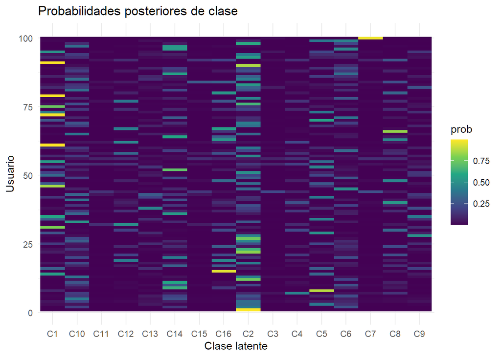

```r
heatmap_df <- as.data.frame(post_class)

colnames(heatmap_df) <- paste0(
  "C",
  seq_len(ncol(post_class))
)

heatmap_df$user <- seq_len(nrow(post_class))

heatmap_df <- pivot_longer(
  heatmap_df,
  -user,
  names_to = "class",
  values_to = "prob"
)

ggplot(
  heatmap_df,
  aes(class,user,fill=prob)
) +
  geom_tile() +
  scale_fill_viridis_c() +
  labs(
    title = "Probabilidades posteriores de clase",
    x = "Clase latente",
    y = "Usuario"
  ) +
  theme_minimal()
```

```r
perfil_usuario <- alpha_class[clase_usuario,]

profile_mean <- colMeans( perfil_usuario)

profile_mean
```

```
   Drama   Comedy Thriller  Romance
    0.75     0.22     0.39     0.31
```

```r
as.data.frame(perfil_usuario) %>%  count( Drama,  Comedy,
                                          Thriller,   Romance,  sort=TRUE )
```

```
   Drama Comedy Thriller Romance  n
1      1      0        0       0 32
2      0      0        0       0 14
3      1      0        1       1 11
4      0      0        1       0  7
5      1      0        0       1  7
6      1      1        1       1  7
7      1      1        1       0  6
8      1      0        1       0  5
9      1      1        0       1  4
10     1      1        0       0  3
11     0      1        1       0  2
12     0      0        0       1  1
13     0      0        1       1  1
```

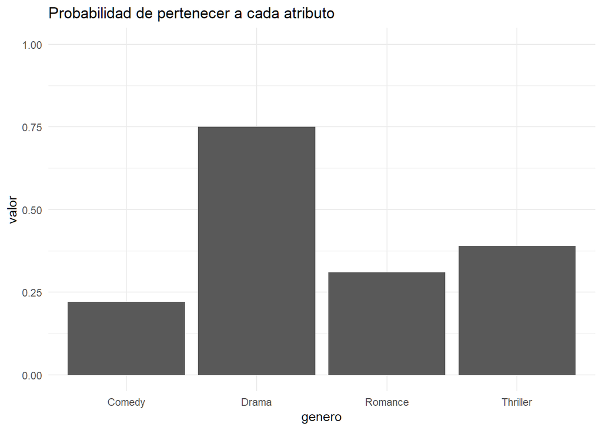

```r
data.frame(
  genero = names(profile_mean),
  valor  = profile_mean
) %>%
  ggplot(
    aes(genero,valor)
  ) +
  geom_col() +
  ylim(0,1) +
  labs(
    title="Probabilidad de pertenecer a cada atributo"
  ) +
  theme_minimal()
```